# All the relevant code, reporting and contentfor completing the P2 project will be done here

# Data Analysis:Ask one or more questions regarding the data that will be answered during the course of the project execution

1. How does survival rate vary across socio-economic classes?
2. How did survivability vary across age groups in this sample? Can we use some graphs to visualise this? Will it be safe to say that some age-groups were more likely to survive?
3. Similar to Qn 2, can we evaluate how survivability changes across gender?

```python
# Import all the relevant modules for running code on this project. Numpy, Pandas & matplotlib.pyplot for plotting the data
import numpy as np
import pandas as pd
import matplotlib.pyplot as plt
import seaborn as sns
```

```python
#Loading data from the csv file on a pandas dataframe
filename = 'C:/Users/pvatsa/Downloads/Personal/Coursework/Udacity/Data Analyst Nanodegree/P2 - Analyze a dataset/P2 project submission/titanic_data.csv'
titanicdata_df = pd.read_csv(filename)
```

```python
#Checking data types
titanicdata_df.dtypes
```

```
PassengerId      int64
Survived         int64
Pclass           int64
Name            object
Sex             object
Age            float64
SibSp            int64
Parch            int64
Ticket          object
Fare           float64
Cabin           object
Embarked        object
dtype: object
```

```python
#defining a function to return every element in the dataframe after squaring it
def square(x):
    return x**2
```

```python
#Getting a feel for the data
titanicdata_df.describe()
```

|  | PassengerId | Survived | Pclass | Age | SibSp | Parch | Fare |
| --- | --- | --- | --- | --- | --- | --- | --- |
| count | 891.000000 | 891.000000 | 891.000000 | 714.000000 | 891.000000 | 891.000000 | 891.000000 |
| mean | 446.000000 | 0.383838 | 2.308642 | 29.699118 | 0.523008 | 0.381594 | 32.204208 |
| std | 257.353842 | 0.486592 | 0.836071 | 14.526497 | 1.102743 | 0.806057 | 49.693429 |
| min | 1.000000 | 0.000000 | 1.000000 | 0.420000 | 0.000000 | 0.000000 | 0.000000 |
| 25% | 223.500000 | 0.000000 | 2.000000 | 20.125000 | 0.000000 | 0.000000 | 7.910400 |
| 50% | 446.000000 | 0.000000 | 3.000000 | 28.000000 | 0.000000 | 0.000000 | 14.454200 |
| 75% | 668.500000 | 1.000000 | 3.000000 | 38.000000 | 1.000000 | 0.000000 | 31.000000 |
| max | 891.000000 | 1.000000 | 3.000000 | 80.000000 | 8.000000 | 6.000000 | 512.329200 |

```python
titanicdata_df[['Ticket', 'Cabin','Sex','Name', 'Embarked']].describe()
```

|  | Ticket | Cabin | Sex | Name | Embarked |
| --- | --- | --- | --- | --- | --- |
| count | 891 | 204 | 891 | 891 | 889 |
| unique | 681 | 147 | 2 | 891 | 3 |
| top | CA. 2343 | C23 C25 C27 | male | Graham, Mr. George Edward | S |
| freq | 7 | 4 | 577 | 1 | 644 |

# Data Wrangling

```python
#Checking for NaN in the data
titanicdata_df.loc[pd.isnull(titanicdata_df['Embarked'])]
```

|  | PassengerId | Survived | Pclass | Name | Sex | Age | SibSp | Parch | Ticket | Fare | Cabin | Embarked |
| --- | --- | --- | --- | --- | --- | --- | --- | --- | --- | --- | --- | --- |
| 61 | 62 | 1 | 1 | Icard, Miss. Amelie | female | 38 | 0 | 0 | 113572 | 80 | B28 | NaN |
| 829 | 830 | 1 | 1 | Stone, Mrs. George Nelson (Martha Evelyn) | female | 62 | 0 | 0 | 113572 | 80 | B28 | NaN |

```python
#Checking for NaN in the dependent variable. Omit rows wherever found. This is a critical variable in our analysis
titanicdata_df.loc[pd.isnull(titanicdata_df['Survived'])]
```

|  | PassengerId | Survived | Pclass | Name | Sex | Age | SibSp | Parch | Ticket | Fare | Cabin | Embarked |
| --- | --- | --- | --- | --- | --- | --- | --- | --- | --- | --- | --- | --- |

```python
#Checking for NaN in the data
titanicdata_df.loc[pd.isnull(titanicdata_df['Ticket'])]
```

|  | PassengerId | Survived | Pclass | Name | Sex | Age | SibSp | Parch | Ticket | Fare | Cabin | Embarked |
| --- | --- | --- | --- | --- | --- | --- | --- | --- | --- | --- | --- | --- |

```python
#Checking for NaN in the data
print titanicdata_df.loc[pd.isnull(titanicdata_df['Cabin'])]
```

```
     PassengerId  Survived  Pclass  \
0              1         0       3
2              3         1       3
4              5         0       3
5              6         0       3
7              8         0       3
8              9         1       3
9             10         1       2
12            13         0       3
13            14         0       3
14            15         0       3
15            16         1       2
16            17         0       3
17            18         1       2
18            19         0       3
```

[output cut: 175 more lines]

```python
titanicdata_df.loc[pd.isnull(titanicdata_df['Fare'])]
```

|  | PassengerId | Survived | Pclass | Name | Sex | Age | SibSp | Parch | Ticket | Fare | Cabin | Embarked |
| --- | --- | --- | --- | --- | --- | --- | --- | --- | --- | --- | --- | --- |

```python
print titanicdata_df.loc[titanicdata_df['Fare'].isin([0, 0.00,0.0000,0.0])]
```

```
     PassengerId  Survived  Pclass                              Name   Sex  \
179          180         0       3               Leonard, Mr. Lionel  male
263          264         0       1             Harrison, Mr. William  male
271          272         1       3      Tornquist, Mr. William Henry  male
277          278         0       2       Parkes, Mr. Francis "Frank"  male
302          303         0       3   Johnson, Mr. William Cahoone Jr  male
413          414         0       2    Cunningham, Mr. Alfred Fleming  male
466          467         0       2             Campbell, Mr. William  male
481          482         0       2  Frost, Mr. Anthony Wood "Archie"  male
597          598         0       3               Johnson, Mr. Alfred  male
633          634         0       1     Parr, Mr. William Henry Marsh  male
674          675         0       2        Watson, Mr. Ennis Hastings  male
732          733         0       2              Knight, Mr. Robert J  male
806          807         0       1            Andrews, Mr. Thomas Jr  male
815          816         0       1                  Fry, Mr. Richard  male
```

[output cut: 18 more lines]

```python
titanicdata_df.loc[~titanicdata_df['Sex'].isin(['male','female'])]
```

|  | PassengerId | Survived | Pclass | Name | Sex | Age | SibSp | Parch | Ticket | Fare | Cabin | Embarked |
| --- | --- | --- | --- | --- | --- | --- | --- | --- | --- | --- | --- | --- |

```python
titanicdata_df.loc[titanicdata_df['Age'].isin([None])]
```

|  | PassengerId | Survived | Pclass | Name | Sex | Age | SibSp | Parch | Ticket | Fare | Cabin | Embarked |
| --- | --- | --- | --- | --- | --- | --- | --- | --- | --- | --- | --- | --- |

```python
titanicdata_df.loc[titanicdata_df['Age'].isin([0])]
```

|  | PassengerId | Survived | Pclass | Name | Sex | Age | SibSp | Parch | Ticket | Fare | Cabin | Embarked |
| --- | --- | --- | --- | --- | --- | --- | --- | --- | --- | --- | --- | --- |

```python
titanicdata_df.loc[pd.isnull(titanicdata_df['Age'])]
```

[output not shown]

177 rows × 12 columns

```python
titanicdata_df.loc[~titanicdata_df['Pclass'].isin([1,2,3])]
```

|  | PassengerId | Survived | Pclass | Name | Sex | Age | SibSp | Parch | Ticket | Fare | Cabin | Embarked |
| --- | --- | --- | --- | --- | --- | --- | --- | --- | --- | --- | --- | --- |

```python
titanicdata_df.loc[~titanicdata_df['Survived'].isin([0,1])]
```

|  | PassengerId | Survived | Pclass | Name | Sex | Age | SibSp | Parch | Ticket | Fare | Cabin | Embarked |
| --- | --- | --- | --- | --- | --- | --- | --- | --- | --- | --- | --- | --- |

# Analyze the missing data information that we've gathered above for each of the columns in the dataframe.

1. 'Survived' and 'Pclass' have no missing information and have all the values accurately filled as per the permitted values for these categorical variables.
2. 'Age' has 177 rows missing with values = NaN. These will have to be omitted at a later stage when we're doing age related computations and comparisons.
3. I see some noticeable information missing for columns 'Embarked' and 'Cabin' but I don't intend to answer any question around these variables hence this can be ignored.
4. For column 'Fare', I notice something very strange. These values are 0 for a substantial number of rows in the data. This will be fixed in the next section of the workbook.
5. For column 'Sex', all the rows are correctly filled with either 'Male' or 'Female', the only two values for this categorical variable as far as this study is concerned.
6. No missing data tests have been done for the columns: 'Name', 'SibSp' & 'Parch'

```python
#Handle missing data. Define a function to handle the missing data in the fare column as per point #4 above
def replace_fare(grp):
    grp['FareNew'] = grp['Fare'].median()
    return grp
```

```python
#Create a new column in the dataset consisting of the median fare of each group
titanicdata_df = titanicdata_df.groupby('Pclass').apply(replace_fare)
```

```python
#Replace fare median values for the actual fare values that we have where original value not equal to zero
titanicdata_df['FareNew'] = np.where((titanicdata_df['Fare'] !=0), titanicdata_df['Fare'],titanicdata_df['FareNew'])
```

```python
#View of a dataframe after dropping the 'Fare' column. Inplace argument is set to false by default. Hence no change has been made
#to the original dataframe. THis is just a view of the dataframe. I'm retaining the fare column just in case.
titanicdata_df.drop('Fare', axis = 'columns')
```

[output not shown]

891 rows × 12 columns

Data is cleaned now. We will now run some statistical tests to check for correlation, visualization and statistical significance wherever applicable. For my analysis, I've taken survived as the dependent variable and Pclass, age, sex as the independent variables.

# Exploration Phase

Question 1.

```python
titanicdata_df.corr()
```

|  | PassengerId | Survived | Pclass | Age | SibSp | Parch | Fare | FareNew |
| --- | --- | --- | --- | --- | --- | --- | --- | --- |
| PassengerId | 1.000000 | -0.005007 | -0.035144 | 0.036847 | -0.057527 | -0.001652 | 0.012658 | 0.018753 |
| Survived | -0.005007 | 1.000000 | -0.338481 | -0.077221 | -0.035322 | 0.081629 | 0.257307 | 0.250635 |
| Pclass | -0.035144 | -0.338481 | 1.000000 | -0.369226 | 0.083081 | 0.018443 | -0.549500 | -0.561243 |
| Age | 0.036847 | -0.077221 | -0.369226 | 1.000000 | -0.308247 | -0.189119 | 0.096067 | 0.099377 |
| SibSp | -0.057527 | -0.035322 | 0.083081 | -0.308247 | 1.000000 | 0.414838 | 0.159651 | 0.155423 |
| Parch | -0.001652 | 0.081629 | 0.018443 | -0.189119 | 0.414838 | 1.000000 | 0.216225 | 0.212103 |
| Fare | 0.012658 | 0.257307 | -0.549500 | 0.096067 | 0.159651 | 0.216225 | 1.000000 | 0.995568 |
| FareNew | 0.018753 | 0.250635 | -0.561243 | 0.099377 | 0.155423 | 0.212103 | 0.995568 | 1.000000 |

# Pearson correlation coefficient,r, measures the linear relationship between two variables. Hence it is only relevant for a bivariate data set. The value of coefficient varies between -1 and 1.

```python
#Let's look at some visualizations for this relationship.
titanicdata_df.groupby('Pclass').mean()
```

| Pclass | PassengerId | Survived | Age | SibSp | Parch | Fare | FareNew |
| --- | --- | --- | --- | --- | --- | --- | --- |
| 1 | 461.597222 | 0.629630 | 38.233441 | 0.416667 | 0.356481 | 84.154687 | 85.550231 |
| 2 | 445.956522 | 0.472826 | 29.877630 | 0.402174 | 0.380435 | 20.662183 | 21.126857 |
| 3 | 439.154786 | 0.242363 | 25.140620 | 0.615071 | 0.393075 | 13.675550 | 13.741131 |

```python
titanicdata_df.groupby('Pclass').count()
```

| Pclass | PassengerId | Survived | Name | Sex | Age | SibSp | Parch | Ticket | Fare | Cabin | Embarked | FareNew |
| --- | --- | --- | --- | --- | --- | --- | --- | --- | --- | --- | --- | --- |
| 1 | 216 | 216 | 216 | 216 | 186 | 216 | 216 | 216 | 216 | 176 | 214 | 216 |
| 2 | 184 | 184 | 184 | 184 | 173 | 184 | 184 | 184 | 184 | 16 | 184 | 184 |
| 3 | 491 | 491 | 491 | 491 | 355 | 491 | 491 | 491 | 491 | 12 | 491 | 491 |

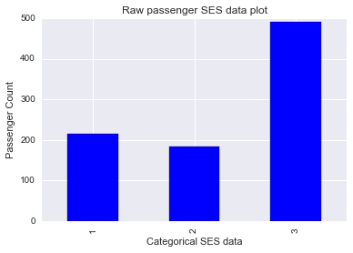

```python
#1D analysis
%matplotlib inline
total_passengers_by_class = titanicdata_df.groupby('Pclass').count()['PassengerId']
total_passengers_by_class.plot.bar()
plt.ylabel('Passenger Count')
plt.xlabel('Categorical SES data')
plt.title('Raw passenger SES data plot')
```

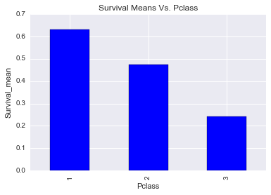

```python
#2D analysis
%matplotlib inline
survival_mean_by_class = titanicdata_df.groupby('Pclass').mean()['Survived']
survival_summary_by_class = titanicdata_df.groupby('Pclass').sum()['Survived']
survival_mean_by_class.plot.bar()
plt.ylabel('Survival_mean')
plt.xlabel('Pclass')
plt.title('Survival Means Vs. Pclass')
```

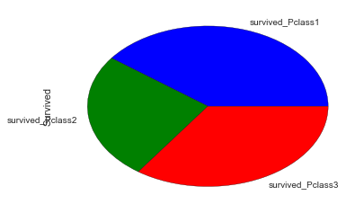

```python
survived_Pclass1 = titanicdata_df.groupby('Pclass').get_group(1).sum()['Survived']
survived_Pclass2 = titanicdata_df.groupby('Pclass').get_group(2).sum()['Survived']
survived_Pclass3 = titanicdata_df.groupby('Pclass').get_group(3).sum()['Survived']
survival_summary_by_class.plot.pie(labels = ['survived_Pclass1', 'survived_Pclass2', 'survived_Pclass3'])
```

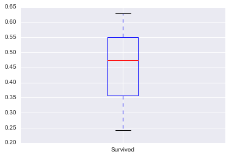

```python
%matplotlib inline
survival_mean_by_class.plot.box()
```

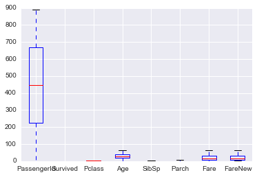

```python
%matplotlib inline
titanicdata_df.plot.box()
```

```python
#Step I: A contingency table
ct_Pclass_survivability = pd.pivot_table(data = titanicdata_df[['Survived', 'Pclass']], index = 'Survived', columns = 'Pclass',
                                        aggfunc = len, margins = True)
ct_Pclass_survivability
```

| Pclass Survived | 1 | 2 | 3 | All |
| --- | --- | --- | --- | --- |
| 0 | 80 | 97 | 372 | 549 |
| 1 | 136 | 87 | 119 | 342 |
| All | 216 | 184 | 491 | 891 |

```python
ct_Pclass_survivability_no_margins = pd.pivot_table(data = titanicdata_df[['Survived', 'Pclass']], index = 'Survived',
                                                    columns = 'Pclass',  aggfunc = len, margins = False)
```

```python
#Step II: Hypotheses
#Ho: Pclass and survival rates are not associated or independent
#Ha: Pclass and survival rates are associated
```

```python
#Step III: Formulate an analysis plan
#Significance level: alpha = 0.05
#chi-square test for independence will be the test that we will do here
```

```python
#Step IV
#Computing the degrees of freedom
df = (len(ct_Pclass_survivability_no_margins.index) - 1)*(len(ct_Pclass_survivability_no_margins.columns)- 1) #df is degrees of freedom
print df
n = ct_Pclass_survivability.loc['All', 'All'] #this is the common denominator for our computations
print n
E11 = ct_Pclass_survivability.loc['All', 1]* ct_Pclass_survivability.loc[0, 'All']/float(n)
E12 = ct_Pclass_survivability.loc['All', 2]* ct_Pclass_survivability.loc[0, 'All']/float(n)
E13 = ct_Pclass_survivability.loc['All', 3]* ct_Pclass_survivability.loc[0, 'All']/float(n)
E21 = ct_Pclass_survivability.loc['All', 1]* ct_Pclass_survivability.loc[1, 'All']/float(n)
E22 = ct_Pclass_survivability.loc['All', 2]* ct_Pclass_survivability.loc[1, 'All']/float(n)
E23 = ct_Pclass_survivability.loc['All', 3]* ct_Pclass_survivability.loc[1, 'All']/float(n)
arrays = [[0,1]]
tuples = list(zip(*arrays))
index = pd.MultiIndex.from_tuples(tuples, names = ['Survived'])
print index
expected_values_Pclass_df = pd.DataFrame(
                    data  = [[E11, E12, E13],
                             [E21, E22, E23]],
                    columns = [1, 2, 3],
                    index = index
)
expected_values_Pclass_df
```

```
2
891.0
Int64Index([0, 1], dtype='int64', name=u'Survived')
```

| Survived | 1 | 2 | 3 |
| --- | --- | --- | --- |
| 0 | 133.090909 | 113.373737 | 302.535354 |
| 1 | 82.909091 | 70.626263 | 188.464646 |

```python
Pclass_diff_df = ct_Pclass_survivability_no_margins - expected_values_Pclass_df
Pclass_diff_df
```

| Pclass Survived | 1 | 2 | 3 |
| --- | --- | --- | --- |
| 0 | -53.090909 | -16.373737 | 69.464646 |
| 1 | 53.090909 | 16.373737 | -69.464646 |

```python
Pclass_squared_df = Pclass_diff_df.applymap(square)
Pclass_squared_df
```

| Pclass Survived | 1 | 2 | 3 |
| --- | --- | --- | --- |
| 0 | 2818.644628 | 268.099276 | 4825.337108 |
| 1 | 2818.644628 | 268.099276 | 4825.337108 |

```python
X2_df = Pclass_squared_df/expected_values_Pclass_df
X2_df
```

| Pclass Survived | 1 | 2 | 3 |
| --- | --- | --- | --- |
| 0 | 21.178341 | 2.364739 | 15.949664 |
| 1 | 33.996810 | 3.796028 | 25.603407 |

```python
X2 = X2_df.values.sum()
X2
```

```
102.88898875696056
```

Step V: Interpreting the result The above value, X2, is the test statistic, the chi square random variable. Now, at this value of chi square statistic and df = 2, we find the P-value from the chi-square distribution calculator. P(X^2 > 102.8889) ~ 0.0 which is less than the significance level of 0.05 Therefore, we reject the null hypothesis.Therefore, there is a definite relationship between Pclass and survival. We can't ascertain for sure, whether this is causal or not.

# Question 2.

```python
#cleaning the titanic data of all the NaN values in the age column
age_cleaned_titanic_df = titanicdata_df[titanicdata_df.Age.notnull()]
```

```python
#the new dataframe has no NaN values. Now for all age related comparisons we can use this dataframe.
age_cleaned_titanic_df.loc[pd.isnull(titanicdata_df['Age'])]
```

|  | PassengerId | Survived | Pclass | Name | Sex | Age | SibSp | Parch | Ticket | Fare | Cabin | Embarked | FareNew |
| --- | --- | --- | --- | --- | --- | --- | --- | --- | --- | --- | --- | --- | --- |

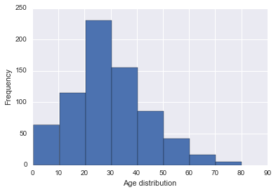

```python
#1D analysis
%matplotlib inline
age_cleaned_titanic_df['Age'].plot.hist(bins = 8)
plt.xlabel('Age distribution')
```

```python
age_cleaned_titanic_df['Age'].describe()
```

```
count    714.000000
mean      29.699118
std       14.526497
min        0.420000
25%       20.125000
50%       28.000000
75%       38.000000
max       80.000000
Name: Age, dtype: float64
```

```
17.875
64.8125 -6.6875
```

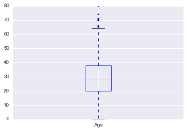

```python
#1D analysis using box plot
%matplotlib inline
age_cleaned_titanic_df['Age'].plot.box( sym = 'k.')
#IQR = Q3 - Q1
IQR = 38 - 20.125
print IQR
#Outlier_1 > Q3 + 1.5*IQR or <Q1 - 1.5*IQR
Outlier_1 = 38 + 1.5*IQR
Outlier_2 = 20.125 - 1.5*IQR
print Outlier_1, Outlier_2
#Since there are no negative age values in the data, therefore all outliers are data points > 64.8125
```

```python
#With age, it'll be more relevant to convert ages into age-groups to analyse the data. This will give us more insight. Writing a
#function for the same. This function returns half-open bins with right intervals included and left intervals excluded
def age_group(df):
    bins = np.linspace(0,80,9)
    df.loc[:,'Age_group'] = pd.cut(df.loc[:,'Age'], bins, include_lowest = True)
    return df
```

```python
age_group(age_cleaned_titanic_df)
```

[output not shown]

714 rows × 14 columns

```python
age_cleaned_titanic_df.groupby('Age_group').sum()
```

| Age_group | PassengerId | Survived | Pclass | Age | SibSp | Parch | Fare | FareNew |
| --- | --- | --- | --- | --- | --- | --- | --- | --- |
| [0, 10] | 27574 | 38 | 169 | 273.17 | 118 | 91 | 1947.8041 | 1947.8041 |
| (10, 20] | 51481 | 44 | 291 | 1991.50 | 68 | 45 | 3395.8961 | 3403.9461 |
| (20, 30] | 98597 | 84 | 549 | 5847.50 | 74 | 55 | 6510.5453 | 6518.5953 |
| (30, 40] | 72647 | 69 | 324 | 5433.00 | 58 | 61 | 6586.8955 | 6775.8080 |
| (40, 50] | 41581 | 33 | 165 | 3902.00 | 32 | 37 | 3540.0336 | 3548.0836 |
| (50, 60] | 18892 | 17 | 64 | 2305.50 | 13 | 13 | 1880.5417 | 1880.5417 |
| (60, 70] | 7325 | 4 | 26 | 1086.00 | 3 | 6 | 780.4833 | 780.4833 |
| (70, 80] | 2191 | 1 | 9 | 366.50 | 0 | 0 | 129.6834 | 129.6834 |

```python
age_cleaned_titanic_df.groupby('Age_group').sum()['Survived']
```

```
Age_group
[0, 10]     38
(10, 20]    44
(20, 30]    84
(30, 40]    69
(40, 50]    33
(50, 60]    17
(60, 70]     4
(70, 80]     1
Name: Survived, dtype: int64
```

```python
survival_summary_by_age = age_cleaned_titanic_df.groupby('Age_group').sum()['Survived']
```

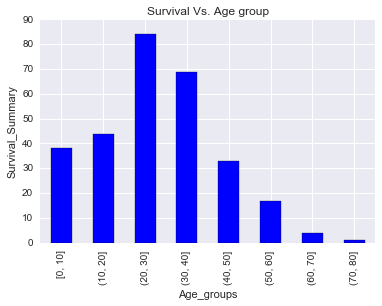

```python
#2D Analysis
#Plotting a bar graph to plot the age group data Vs. Survival summary
%matplotlib inline
survival_summary_by_age.plot.bar()
plt.ylabel('Survival_Summary')
plt.xlabel('Age_groups')
plt.title('Survival Vs. Age group')
```

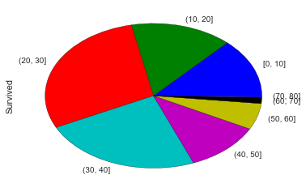

```python
#Plotting a pie chart to summarize the survival summar.plot.pie()
survival_summary_by_age.plot.pie()
```

# This doesn't give me enough insight because this is absolute information regarding age_group data for survival summary. What will be interesting to see is what is the mean value of Survived class in each age group. Since Survived is a categorical variable with 1 assigned only to those who've survived, higher mean survived value will indicate higher likelyhood of surival in that age group.

Nevertheless, the pie plot gives me information about which is the largest group in terms of number of survivors. (20,30] seems to have the most number of survivors but it could be due to higher number of passengers belonging to that group. Therefore, let's look at mean survival rate per age group.

```python
age_cleaned_titanic_df.groupby('Age_group').mean()['Survived']
```

```
Age_group
[0, 10]     0.593750
(10, 20]    0.382609
(20, 30]    0.365217
(30, 40]    0.445161
(40, 50]    0.383721
(50, 60]    0.404762
(60, 70]    0.235294
(70, 80]    0.200000
Name: Survived, dtype: float64
```

```python
survival_mean_by_age_group = age_cleaned_titanic_df.groupby('Age_group').mean()['Survived']
```

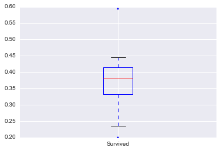

```python
%matplotlib inline
survival_mean_by_age_group.plot.box(sym = 'k.')
```

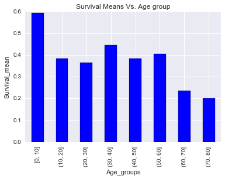

```python
#2D Analysis
survival_mean_by_age_group.plot.bar()
plt.ylabel('Survival_mean')
plt.xlabel('Age_groups')
plt.title('Survival Means Vs. Age group')
```

# This looks like following. The peak is at (0,10] thus indicating that saving infants and kids was somewhat a priority. Maybe, even rescue missions focused on rescuing children first as that is a more common strategy in case of catastrophes. The correlation coefficient between age and survived is ~0 (from our earlier correlation matrix) which suggests that there was weak linear relation between age of the passenger and odds of his survival. Now let's run some statistical tests to explore further. We'll first create a contingency table to plot the two categorical variables age_group and survived

```python
#create contingency table
#Age groups to survivability
ct_table_age_group = pd.pivot_table(data = age_cleaned_titanic_df[['Survived', 'Age_group']], index = 'Survived', \
                                    columns = ['Age_group'], aggfunc=len, margins = True)
ct_table_age_group
```

| Age_group Survived | (10, 20] | (20, 30] | (30, 40] | (40, 50] | (50, 60] | (60, 70] | (70, 80] | [0, 10] | All |
| --- | --- | --- | --- | --- | --- | --- | --- | --- | --- |
| 0 | 71 | 146 | 86 | 53 | 25 | 13 | 4 | 26 | 424 |
| 1 | 44 | 84 | 69 | 33 | 17 | 4 | 1 | 38 | 290 |
| All | 115 | 230 | 155 | 86 | 42 | 17 | 5 | 64 | 714 |

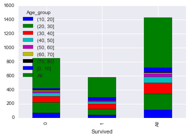

```python
ct_table_age_group.plot.bar(stacked = True)
```

Chi-square test for independence: This test is used to compute whether there is a significant association between two categorical variables. Firstly, I will state the hypotheses. Ho: The two categorical variables, 'Survived' and 'Age_group' are independent i.e. there is no impact of age group on survival Ha: The two variables are not independent i.e. there is impact of age group on survival Assumption: The significance level is alpha = 0.05 for this test.

```python
ct_table_age_group_no_margin = pd.pivot_table(data = age_cleaned_titanic_df[['Survived', 'Age_group']], index = 'Survived', \
                                    columns = ['Age_group'], aggfunc=len, margins = False)
```

```python
arrays = [[0,1]]
tuples = list(zip(*arrays))
index = pd.MultiIndex.from_tuples(tuples, names = ['Survived'])
index
```

```
Int64Index([0, 1], dtype='int64', name=u'Survived')
```

```python
#Doing the Chi-square test of independence
#Computing the degrees of freedom
df = (len(ct_table_age_group_no_margin.index) - 1)*(len(ct_table_age_group_no_margin.columns)- 1) #df is degrees of freedom
print df
n = ct_table_age_group.loc['All', 'All'] #this is the common denominator for our computations
print n
E11 = ct_table_age_group.loc['All', '(10, 20]']* ct_table_age_group.loc[0, 'All']/float(n)
E12 = ct_table_age_group.loc['All', '(20, 30]']* ct_table_age_group.loc[0, 'All']/float(n)
E13 = ct_table_age_group.loc['All', '(30, 40]']* ct_table_age_group.loc[0, 'All']/float(n)
E14 = ct_table_age_group.loc['All', '(40, 50]']* ct_table_age_group.loc[0, 'All']/float(n)
E15 = ct_table_age_group.loc['All', '(50, 60]']* ct_table_age_group.loc[0, 'All']/float(n)
E16 = ct_table_age_group.loc['All', '(60, 70]']* ct_table_age_group.loc[0, 'All']/float(n)
E17 = ct_table_age_group.loc['All', '(70, 80]']* ct_table_age_group.loc[0, 'All']/float(n)
E18 = ct_table_age_group.loc['All', '[0, 10]']* ct_table_age_group.loc[0, 'All']/float(n)
E21 = ct_table_age_group.loc['All', '(10, 20]']* ct_table_age_group.loc[1, 'All']/float(n)
E22 = ct_table_age_group.loc['All', '(20, 30]']* ct_table_age_group.loc[1, 'All']/float(n)
E23 = ct_table_age_group.loc['All', '(30, 40]']* ct_table_age_group.loc[1, 'All']/float(n)
E24 = ct_table_age_group.loc['All', '(40, 50]']* ct_table_age_group.loc[1, 'All']/float(n)
E25 = ct_table_age_group.loc['All', '(50, 60]']* ct_table_age_group.loc[1, 'All']/float(n)
E26 = ct_table_age_group.loc['All', '(60, 70]']* ct_table_age_group.loc[1, 'All']/float(n)
E27 = ct_table_age_group.loc['All', '(70, 80]']* ct_table_age_group.loc[1, 'All']/float(n)
E28 = ct_table_age_group.loc['All', '[0, 10]']* ct_table_age_group.loc[1, 'All']/float(n)
expected_values_df = pd.DataFrame(
                    data = [[E11, E12, E13, E14, E15, E16, E17, E18],
                           [E21, E22, E23, E24, E25, E26, E27, E28]],
                    columns = ['(10, 20]', '(20, 30]' , '(30, 40]', '(40, 50]', '(50, 60]', '(60, 70]', '(70, 80]', '[0, 10]'],

                    index = index
    )
```

```
7
714.0
```

```python
expected_values_df
```

| Survived | (10, 20] | (20, 30] | (30, 40] | (40, 50] | (50, 60] | (60, 70] | (70, 80] | [0, 10] |
| --- | --- | --- | --- | --- | --- | --- | --- | --- |
| 0 | 68.291317 | 136.582633 | 92.044818 | 51.070028 | 24.941176 | 10.095238 | 2.969188 | 38.005602 |
| 1 | 46.708683 | 93.417367 | 62.955182 | 34.929972 | 17.058824 | 6.904762 | 2.030812 | 25.994398 |

```python
ct_table_age_group_no_margin - expected_values_df
```

| Age_group Survived | (10, 20] | (20, 30] | (30, 40] | (40, 50] | (50, 60] | (60, 70] | (70, 80] | [0, 10] |
| --- | --- | --- | --- | --- | --- | --- | --- | --- |
| 0 | 2.708683 | 9.417367 | -6.044818 | 1.929972 | 0.058824 | 2.904762 | 1.030812 | -12.005602 |
| 1 | -2.708683 | -9.417367 | 6.044818 | -1.929972 | -0.058824 | -2.904762 | -1.030812 | 12.005602 |

```python
X2_array = ct_table_age_group_no_margin - expected_values_df
def square(x):
    return x**2
X2_array.applymap(square)
```

| Age_group Survived | (10, 20] | (20, 30] | (30, 40] | (40, 50] | (50, 60] | (60, 70] | (70, 80] | [0, 10] |
| --- | --- | --- | --- | --- | --- | --- | --- | --- |
| 0 | 7.336966 | 88.6868 | 36.539824 | 3.724792 | 0.00346 | 8.437642 | 1.062574 | 144.134485 |
| 1 | 7.336966 | 88.6868 | 36.539824 | 3.724792 | 0.00346 | 8.437642 | 1.062574 | 144.134485 |

```python
X2_df = X2_array.applymap(square)
X2_df/expected_values_df
```

| Age_group Survived | (10, 20] | (20, 30] | (30, 40] | (40, 50] | (50, 60] | (60, 70] | (70, 80] | [0, 10] |
| --- | --- | --- | --- | --- | --- | --- | --- | --- |
| 0 | 0.107436 | 0.649327 | 0.396979 | 0.072935 | 0.000139 | 0.835804 | 0.357867 | 3.792454 |
| 1 | 0.157079 | 0.949361 | 0.580410 | 0.106636 | 0.000203 | 1.222003 | 0.523226 | 5.544829 |

```python
X2_df_sum = X2_df/expected_values_df
print X2_df_sum.values.sum() #doing summation to get the test statistic for chi-square test for independence
```

```
15.2966877495
```

```python
X2 = X2_df_sum.values.sum()
#This is the test statistic, the chi square random variable. Now, at this value of chi square statistic and df = 7, we find the
#P-value from the chi-square distribution calculator. P(X^2 > 15.29668) = 0.03 which is less than the significance level of 0.05
#Therefore, we reject the null hypothesis.Therefore, there is a relationship between age group and survival. We can't ascertain
#for sure, whether this is causal or not.
#One must notice the importance of alpha = 0.05 as a significance level here. Had the significance level been 0.01, H0 would've
#been retained and we could've said that there is no relationship between age group and survival.
```

# Question 3

Now we look at grouping this data by gender and visualizing the data for these group labels. Since our column for gender has no missing/incorrect data, we use the original dataframe titanicdata_df to perform these computations.

```python
titanicdata_df.groupby('Sex').sum()
```

| Sex | PassengerId | Survived | Pclass | Age | SibSp | Parch | Fare | FareNew |
| --- | --- | --- | --- | --- | --- | --- | --- | --- |
| female | 135343 | 233 | 678 | 7286.00 | 218 | 204 | 13966.6628 | 13966.6628 |
| male | 262043 | 109 | 1379 | 13919.17 | 248 | 136 | 14727.2865 | 15146.4240 |

```python
titanicdata_df.groupby('Sex').size()
```

```
Sex
female    314
male      577
dtype: int64
```

```python
titanicdata_df.groupby('Sex').mean()
```

| Sex | PassengerId | Survived | Pclass | Age | SibSp | Parch | Fare | FareNew |
| --- | --- | --- | --- | --- | --- | --- | --- | --- |
| female | 431.028662 | 0.742038 | 2.159236 | 27.915709 | 0.694268 | 0.649682 | 44.479818 | 44.479818 |
| male | 454.147314 | 0.188908 | 2.389948 | 30.726645 | 0.429809 | 0.235702 | 25.523893 | 26.250302 |

This indicates that <20% of total males in the dataset have survived since the sum and mean of survived data is only contributed by 1s and hence takes into account those who have survived the crash. Almost 75% of females have survived the crash. These are telling statistic to measure the survival probability based on gender. Let's plot a bar graph now to visualize this.

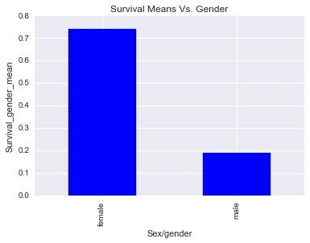

```python
survival_by_gender = titanicdata_df.groupby('Sex').mean()['Survived']
survival_by_gender.plot.bar()
plt.ylabel('Survival_gender_mean')
plt.xlabel('Sex/gender')
plt.title('Survival Means Vs. Gender')
```

```python
#Now let's look at some linear correlation between the two variables. For this, we need to convert gender variable into numeric
#values. For the sake of this exercise, female = 0 and male = 1.
def gender_numeric(df):
    df['gender_numeric'] = np.where(df['Sex'] == 'female', 0, 1)
    return df
```

```python
gender_numeric(titanicdata_df)
```

[output not shown]

891 rows × 14 columns

```python
titanicdata_df.corr()
```

|  | PassengerId | Survived | Pclass | Age | SibSp | Parch | Fare | FareNew | gender_numeric |
| --- | --- | --- | --- | --- | --- | --- | --- | --- | --- |
| PassengerId | 1.000000 | -0.005007 | -0.035144 | 0.036847 | -0.057527 | -0.001652 | 0.012658 | 0.018753 | 0.042939 |
| Survived | -0.005007 | 1.000000 | -0.338481 | -0.077221 | -0.035322 | 0.081629 | 0.257307 | 0.250635 | -0.543351 |
| Pclass | -0.035144 | -0.338481 | 1.000000 | -0.369226 | 0.083081 | 0.018443 | -0.549500 | -0.561243 | 0.131900 |
| Age | 0.036847 | -0.077221 | -0.369226 | 1.000000 | -0.308247 | -0.189119 | 0.096067 | 0.099377 | 0.093254 |
| SibSp | -0.057527 | -0.035322 | 0.083081 | -0.308247 | 1.000000 | 0.414838 | 0.159651 | 0.155423 | -0.114631 |
| Parch | -0.001652 | 0.081629 | 0.018443 | -0.189119 | 0.414838 | 1.000000 | 0.216225 | 0.212103 | -0.245489 |
| Fare | 0.012658 | 0.257307 | -0.549500 | 0.096067 | 0.159651 | 0.216225 | 1.000000 | 0.995568 | -0.182333 |
| FareNew | 0.018753 | 0.250635 | -0.561243 | 0.099377 | 0.155423 | 0.212103 | 0.995568 | 1.000000 | -0.175647 |
| gender_numeric | 0.042939 | -0.543351 | 0.131900 | 0.093254 | -0.114631 | -0.245489 | -0.182333 | -0.175647 | 1.000000 |

```python
titanicdata_df.groupby('gender_numeric', as_index = False).mean()
```

|  | gender_numeric | PassengerId | Survived | Pclass | Age | SibSp | Parch | Fare | FareNew |
| --- | --- | --- | --- | --- | --- | --- | --- | --- | --- |
| 0 | 0 | 431.028662 | 0.742038 | 2.159236 | 27.915709 | 0.694268 | 0.649682 | 44.479818 | 44.479818 |
| 1 | 1 | 454.147314 | 0.188908 | 2.389948 | 30.726645 | 0.429809 | 0.235702 | 25.523893 | 26.250302 |

With this we can say the mean survival rate of women is much higher than men. So being a woman is likely to help you survive. That said, these findings are tentative at best and a more rigourous statistic test is required to understand whether these results hold statistical ground.

A statistical test is required to prove any association between gender and survivability. Since these both are categorical variables, I'd choose a chi-square test for the same. In this test, there are four steps to come to a conclusion: Step I: Build a contingency table Step II: State the hypotheses for the tests Step III: Formulate an analysis plan Step IV: Analyze data Step V: Interpret results

```python
#Step I: A contingency table
ct_gender_survivability = pd.pivot_table(data = titanicdata_df[['Survived', 'Sex']], index = 'Survived', columns = 'Sex',
                                        aggfunc = len, margins = True)
ct_gender_survivability
```

| Sex Survived | female | male | All |
| --- | --- | --- | --- |
| 0 | 81 | 468 | 549 |
| 1 | 233 | 109 | 342 |
| All | 314 | 577 | 891 |

```python
ct_gender_survivability_no_margin = pd.pivot_table(data = titanicdata_df[['Survived', 'Sex']], index = 'Survived', columns = 'Sex',
                                        aggfunc = len, margins = False)
```

```python
#Step II: Hypotheses
#Ho: Gender and survival rates are not associated or independent
#Ha: Gender and survival rates are associated
```

```python
#Step III: Analysis plan
#Significance level is set at alpha = 0.05
#Statistical test to be performed: Chi-square test for independence
```

```python
#Step IV
#Computing the degrees of freedom
df = (len(ct_gender_survivability_no_margin.index) - 1)*(len(ct_gender_survivability_no_margin)- 1) #df is degrees of freedom
print df
n = ct_gender_survivability.loc['All', 'All'] #this is the common denominator for our computations
print n
E11 = ct_gender_survivability.loc['All', 'female']* ct_gender_survivability.loc[0, 'All']/float(n)
E12 = ct_gender_survivability.loc['All', 'male']* ct_gender_survivability.loc[0, 'All']/float(n)
E21 = ct_gender_survivability.loc['All', 'female']* ct_gender_survivability.loc[1, 'All']/float(n)
E22 = ct_gender_survivability.loc['All', 'male']* ct_gender_survivability.loc[1, 'All']/float(n)
arrays = [[0,1]]
tuples = list(zip(*arrays))
index = pd.MultiIndex.from_tuples(tuples, names = ['Survived'])
print index
expected_values_gender_df = pd.DataFrame(
                    data  = [[E11, E12],
                             [E21, E22]],
                    columns = ['female', 'male'],
                    index = index
)
expected_values_gender_df
```

```
1
891.0
Int64Index([0, 1], dtype='int64', name=u'Survived')
```

| Survived | female | male |
| --- | --- | --- |
| 0 | 193.474747 | 355.525253 |
| 1 | 120.525253 | 221.474747 |

```python
chi_table_df = ct_gender_survivability_no_margin - expected_values_gender_df
chi_table_df
```

| Sex Survived | female | male |
| --- | --- | --- |
| 0 | -112.474747 | 112.474747 |
| 1 | 112.474747 | -112.474747 |

```python
chi_table_df.applymap(square)
```

| Sex Survived | female | male |
| --- | --- | --- |
| 0 | 12650.56882 | 12650.56882 |
| 1 | 12650.56882 | 12650.56882 |

```python
X2_sum_gender_df = chi_table_df.applymap(square)/expected_values_gender_df
X2_sum_gender_df
```

| Sex Survived | female | male |
| --- | --- | --- |
| 0 | 65.386150 | 35.582757 |
| 1 | 104.961977 | 57.119690 |

```python
X2_value = X2_sum_gender_df.values.sum()
X2_value
```

```
263.05057407065567
```

Step V: This is the test statistic, the chi square random variable. Now, at this value of chi square statistic and df = 1, we find the P-value from the chi-square distribution calculator. P(X^2 > 263.0505) = 0.0 which is less than the significance level of 0.05 Therefore, we reject the null hypothesis.Therefore, there is a definite relationship between gender and survival. We can't ascertain for sure, whether this is causal or not.

```python
#Now, let's try to see the interplay of data within each sub-groups of independent variables.
titanicdata_df.groupby(('Pclass','Sex')).mean()
```

| Pclass | Sex | PassengerId | Survived | Age | SibSp | Parch | Fare | FareNew | gender_numeric |
| --- | --- | --- | --- | --- | --- | --- | --- | --- | --- |
| 1 | female | 469.212766 | 0.968085 | 34.611765 | 0.553191 | 0.457447 | 106.125798 | 106.125798 | 0 |
|  | male | 455.729508 | 0.368852 | 41.281386 | 0.311475 | 0.278689 | 67.226127 | 69.696926 | 1 |
| 2 | female | 443.105263 | 0.921053 | 28.722973 | 0.486842 | 0.605263 | 21.970121 | 21.970121 | 0 |
|  | male | 447.962963 | 0.157407 | 30.740707 | 0.342593 | 0.222222 | 19.741782 | 20.533449 | 1 |
| 3 | female | 399.729167 | 0.500000 | 21.750000 | 0.895833 | 0.798611 | 16.118810 | 16.118810 | 0 |
|  | male | 455.515850 | 0.135447 | 26.507589 | 0.498559 | 0.224784 | 12.661633 | 12.754428 | 1 |

```python
titanicdata_df.groupby(('Pclass','Sex')).count()
```

| Pclass | Sex | PassengerId | Survived | Name | Age | SibSp | Parch | Ticket | Fare | Cabin | Embarked | FareNew | gender_numeric |
| --- | --- | --- | --- | --- | --- | --- | --- | --- | --- | --- | --- | --- | --- |
| 1 | female | 94 | 94 | 94 | 85 | 94 | 94 | 94 | 94 | 81 | 92 | 94 | 94 |
|  | male | 122 | 122 | 122 | 101 | 122 | 122 | 122 | 122 | 95 | 122 | 122 | 122 |
| 2 | female | 76 | 76 | 76 | 74 | 76 | 76 | 76 | 76 | 10 | 76 | 76 | 76 |
|  | male | 108 | 108 | 108 | 99 | 108 | 108 | 108 | 108 | 6 | 108 | 108 | 108 |
| 3 | female | 144 | 144 | 144 | 102 | 144 | 144 | 144 | 144 | 6 | 144 | 144 | 144 |
|  | male | 347 | 347 | 347 | 253 | 347 | 347 | 347 | 347 | 6 | 347 | 347 | 347 |

```python
survival_by_class_and_gender = titanicdata_df.groupby(('Pclass','Sex')).mean()['Survived']
```

```python
print survival_by_class_and_gender
```

```
Pclass  Sex
1       female    0.968085
        male      0.368852
2       female    0.921053
        male      0.157407
3       female    0.500000
        male      0.135447
Name: Survived, dtype: float64
```

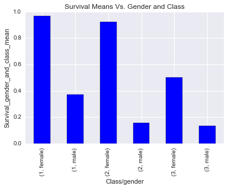

```python
survival_by_class_and_gender.plot.bar()
plt.ylabel('Survival_gender_and_class_mean')
plt.xlabel('Class/gender')
plt.title('Survival Means Vs. Gender and Class')
```

This plot is consistent with our first analysis about correlation between socio-economic status and survival rates. There we saw a negative correlation between values of Pclass and Survived. Even in the plot above, mean survived rates come down for both males and females as socio-economic status decreases from 1 to 3. (P.S. Higher number indicates lower status).